# Ensemble Modeling: Random Forests

Dhrubasattwata Roy Choudhury

## Ensemble Modeling: Random Forests

Random forests are a modification of bagged decision trees that build a large collection of de-correlated trees to further improve predictive performance. They have become a very popular “out-of-the-box” or “off-the-shelf” learning algorithm that enjoys good predictive performance with relatively little hyperparameter tuning. Many modern implementations of random forests exist; however, Leo Breiman’s algorithm (Breiman 2001) has largely become the authoritative procedure.

### Importing the packages

```r
library(dplyr)
```

```r
library(ggplot2)
library(ranger)
library(AmesHousing)
library(rsample)
```

### Datset and Train-Test Split

```r
### Dataset and Train-Test Split
ames <- AmesHousing::make_ames()
# Stratified sampling with the rsample package
set.seed(123)
split <- initial_split(ames, prop = 0.8, strata = "Sale_Price")
ames_train  <- training(split)
ames_test   <- testing(split)
```

### Random Forests: Extending bagging

Random forests are built using the same fundamental principles as decision trees and bagging. Bagging trees introduces a random component into the tree building process by building many trees on bootstrapped copies of the training data. Bagging then aggregates the predictions across all the trees; this aggregation reduces the variance of the overall procedure and results in improved predictive performance. However, simply bagging trees results in tree correlation that limits the effect of variance reduction.

Random forests help to reduce tree correlation by injecting more randomness into the tree-growing process More specifically, while growing a decision tree during the bagging process, random forests perform split-variable randomization where each time a split is to be performed, the search for the split variable is limited to a random subset of the original features. Since the algorithm randomly selects a bootstrap sample to train on and a random sample of features to use at each split, a more diverse set of trees is produced which tends to lessen tree correlation beyond bagged trees and often dramatically increase predictive power.

The basic algorithm for a regression or classification random forest can be generalized as follows:  
1. Given a training data set  
2. Select number of trees to build (n_trees)  
3. for i = 1 to n_trees do  
4. | Generate a bootstrap sample of the original data  
5. | Grow a regression/classification tree to the bootstrapped data  
6. | for each split do  
7. | | Select m_try variables at random from all p variables  
8. | | Pick the best variable/split-point among the m_try  
9. | | Split the node into two child nodes  
10. | end  
11. | Use typical tree model stopping criteria to determine when a tree is complete (but do not prune)  
12. end  
13. Output ensemble of trees

Remember, when split variable is limited to a random subset is equal to the original features Random Forests is equivalent to a Bagging.

### Out-of-the-box performance

Random forests have become popular because they tend to provide very good out-of-the-box performance. Although they have several hyperparameters that can be tuned, the default values tend to produce good results.

### BUILD up the model

```r
# number of features
n_features <- length(setdiff(names(ames_train), "Sale_Price"))

# train a default random forest model
ames_rf1 <- ranger(
  Sale_Price ~ .,
  data = ames_train,
  mtry = floor(n_features / 3),
  respect.unordered.factors = "order",
  seed = 123
)

ames_rf1
```

```
## Ranger result
##
## Call:
##  ranger(Sale_Price ~ ., data = ames_train, mtry = floor(n_features/3),      respect.unordered.factors = "order", seed = 123)
##
## Type:                             Regression
## Number of trees:                  500
## Sample size:                      2346
## Number of independent variables:  80
## Mtry:                             26
## Target node size:                 5
## Variable importance mode:         none
## Splitrule:                        variance
## OOB prediction error (MSE):       607512440
## R squared (OOB):                  0.906003
```

### Performance Metric: RMSE

```r
# get OOB RMSE
default_rmse <- sqrt(ames_rf1$prediction.error)
default_rmse
```

```
## [1] 24647.77
```

### Hypertuning Parameters

Although random forests perform well out-of-the-box, there are several tunable hyperparameters that we should consider when training a model. Although we briefly discuss the main hyperparameters, Probst, Wright, and Boulesteix (2019) provide a much more thorough discussion. The main hyperparameters to consider include:

1. The number of trees in the forest.
2. The number of features to consider at any given split.
3. The complexity of each tree
4. The sampling scheme
5. The splitting rule to use during tree construction

### Tuning strategies

As we introduce more complex algorithms with greater number of hyperparameters, we should become more strategic with our tuning strategies. One way to become more strategic is to consider how we proceed through our grid search. Up to this point, all our grid searches have been full Cartesian grid searches where we assess every combination of hyperparameters of interest. We could continue to do the same; for example, the next code block searches across 120 combinations of hyperparameter settings.

```r
# create hyperparameter grid
hyper_grid <- expand.grid(
  mtry = floor(n_features * c(.05, .15, .25, .333, .4)), # number of features to consider at any given split.
  min.node.size = c(1, 3, 5, 10), # complexity of each tree
  replace = c(TRUE, FALSE),    # sampling scheme
  sample.fraction = c(.5, .63, .8),
  rmse = NA
)

# execute full cartesian grid search
for(i in seq_len(nrow(hyper_grid))) {
  # fit model for ith hyperparameter combination
  fit <- ranger(
    formula         = Sale_Price ~ .,
    data            = ames_train,
    num.trees       = n_features * 10, # number of trees in the forest
    mtry            = hyper_grid$mtry[i],
    min.node.size   = hyper_grid$min.node.size[i],
    replace         = hyper_grid$replace[i],
    sample.fraction = hyper_grid$sample.fraction[i],
    verbose         = FALSE,
    seed            = 123,
    respect.unordered.factors = 'order',
  )
  # export OOB error
  hyper_grid$rmse[i] <- sqrt(fit$prediction.error)
}
```

# Find out the TOP 10 Models

```r
# assess top 10 models
hyper_grid %>%
  arrange(rmse) %>%
  mutate(perc_gain = (default_rmse - rmse) / default_rmse * 100) %>%
  head(10)
```

```
##    mtry min.node.size replace sample.fraction     rmse   perc_gain
## 1    12             5   FALSE            0.80 24600.14  0.19324936
## 2    20             1    TRUE            0.80 24660.41 -0.05127757
## 3    12             3   FALSE            0.80 24679.93 -0.13047216
## 4    26             1   FALSE            0.80 24684.84 -0.15040695
## 5    12             1   FALSE            0.80 24702.91 -0.22370221
## 6    20             1   FALSE            0.63 24702.97 -0.22395281
## 7    20             1   FALSE            0.80 24717.48 -0.28283549
## 8    20             3   FALSE            0.63 24718.33 -0.28628566
## 9    20             1   FALSE            0.50 24745.03 -0.39461255
## 10   26             3    TRUE            0.63 24749.91 -0.41440829
```

### Setting up the Models again with Impurity based and Permutation based Variable Importance

```r
# re-run model with impurity-based variable importance
rf_impurity <- ranger(
  formula = Sale_Price ~ .,
  data = ames_train,
  num.trees = 2000,
  mtry = 32,
  min.node.size = 1,
  sample.fraction = .80,
  replace = FALSE,
  importance = "impurity",
  respect.unordered.factors = "order",
  verbose = FALSE,
  seed  = 123
)

# re-run model with permutation-based variable importance
rf_permutation <- ranger(
  formula = Sale_Price ~ .,
  data = ames_train,
  num.trees = 2000,
  mtry = 32,
  min.node.size = 1,
  sample.fraction = .80,
  replace = FALSE,
  importance = "permutation",
  respect.unordered.factors = "order",
  verbose = FALSE,
  seed  = 123
)
```

### Visualization: VIP

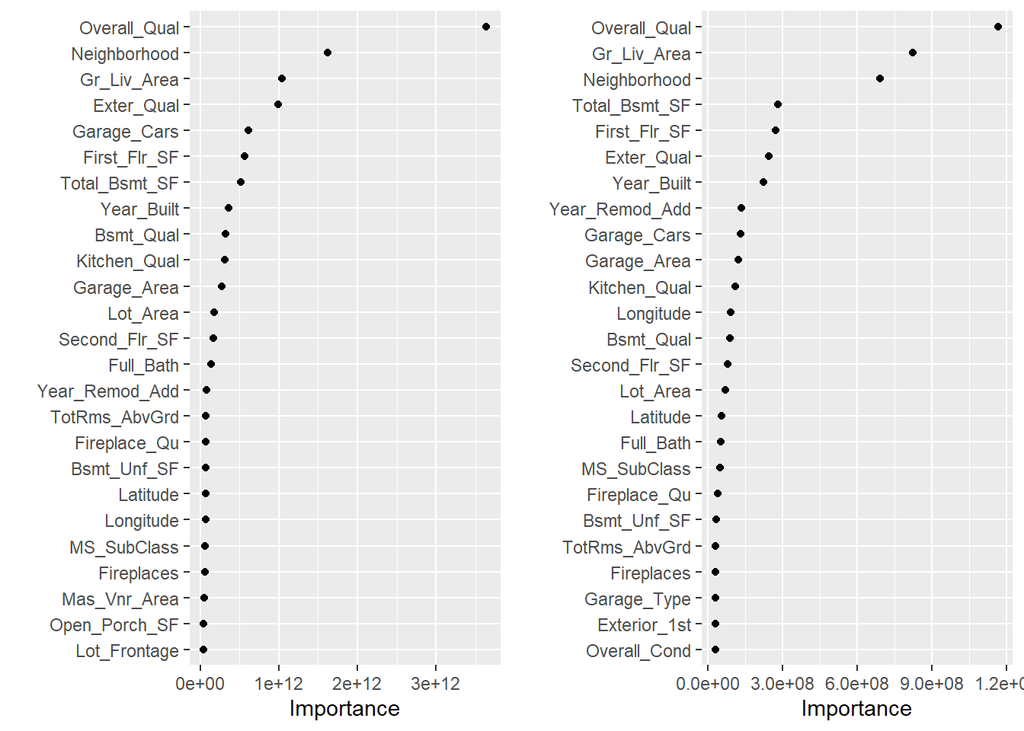

```r
p1 <- suppressWarnings(vip::vip(rf_impurity, num_features = 25, bar = FALSE))
p2 <- suppressWarnings(vip::vip(rf_permutation, num_features = 25, bar = FALSE))

gridExtra::grid.arrange(p1, p2, nrow = 1)
```

We can see that the following variables are important: Overall_Qual, Gr_Liv_Area, Neighborhood

### Conclusion

Final thoughts Random forests provide a very powerful out-of-the-box algorithm that often has great predictive accuracy. They come with all the benefits of decision trees (with the exception of surrogate splits) and bagging but greatly reduce instability and between-tree correlation. And due to the added split variable selection attribute, random forests are also faster than bagging as they have a smaller feature search space at each tree split. However, random forests will still suffer from slow computational speed as your data sets get larger but, similar to bagging, the algorithm is built upon independent steps, and most modern implementations (e.g., ranger) allow for parallelization to improve training time.